# The Guardian Knowledge June 2019

Robert Hickman

2019-06-20

Most wednesday’s I enjoy reading [The Knowledge](https://www.theguardian.com/football/series/theknowledge) blog on the Guardian’s website and reading the football trivia therein. When time (and questions) allow, I like to answer some of the questions posed, example of which are [here](http://www.robert-hickman.eu/post/the-knowledge-4th-august-2018/), [here](http://www.robert-hickman.eu/post/counties_league_points/), and [here](http://www.robert-hickman.eu/post/the-knowledge-7th-february-2019/).

# League of Nations

The first question comes from

> Which player had the nationality with the lowest FIFA World Ranking at the time of him winning the Premier League?

> — The Tin Boonie (@TheTinBoonie) [June 18, 2019](https://twitter.com/TheTinBoonie/status/1140936272862691328?ref_src=twsrc%5Etfw)

a similar question is also answered in thi weeks column:

‘*“Fulham defender Zesh Rehman made his debut for Pakistan, who are ranked 168 by Fifa. Is that the lowest-ranked country a Premier League player has played for?”* wondered Zulfiqar Shah in January 2006.’

I thought I’d answer both of these using R.

First some libraries we’ll need, and also set a seed for reproducibility.

```r
library(tidyverse)
library(magrittr)
library(rvest)

set.seed(3459)
```

The first thing we need to answer these is the nationality of EPL players. For this two good sources are [transfermarkt.co.uk](https://www.transfermarkt.co.uk/) and [11v11.com](https://www.11v11.com/). I’m going to opt for the later, just because the tables are a little easier to scrape.

To start, we need to get the links to every team to have competed in the premier league

```r
# get years of EPL seasons
years <- 1993:2019
# base url we'll scrape from
base_url <- "https://www.11v11.com"

# cat together
tables <- paste0(base_url, "/league-tables/premier-league/01-june-", years)

competing_teams <- tables %>%
  # get a list of the links to every teams squad page
  map(., function(x) {
    x %>%
      read_html() %>%
      html_nodes("#table-league > tbody:nth-child(2) > tr > td:nth-child(2) > a:nth-child(1)") %>%
      html_attr("href") %>%
      # paste into working link for year and competition (EPL)
      paste0(base_url, ., "tab/players/season/", gsub(".*01-june-", "", x), "/comp/1/")
  }) %>%
  unlist()

head(competing_teams, n = 5)
```

We can then scrape the squads for these teams in that specific season. We want the players, their nationality and also the number of appearances they made in the league that season

```r
squads <- competing_teams %>%
  # get the players/appearances/nationalities
  map_df(., function(y) {
    # read once to save server calls
    read <- y %>%
      read_html()

    # get the squad info
    squad <- read %>%
      html_nodes(".squad") %>%
      html_table(fill = TRUE) %>%
      as.data.frame() %>%
      # get rid of rows without player info
      filter(!is.na(Player))

    player_details <- read %>%
      html_nodes(".sortable a")

    df <- data.frame(Player = player_details %>%
                       html_text(),
                     url = player_details %>%
                       html_attr("href"))

    squad <- left_join(squad, df, by = "Player")

    # get the listed nationalities
    flags <- read %>%
      html_nodes(".squad > tbody:nth-child(2) > tr > td:nth-child(3)")

    # from here get the actual nationalities per player
    nations <- flags %>%
      html_nodes("img") %>%
      html_attr("title")

    # these might mismatch in length
    # in which case append NA
    if(length(flags) != length(nations)) {
      missing <- which(!grepl("img", flags))

      nations <- c(nations[1:(missing-1)], NA, nations[missing:length(nations)])
    }

    # mutate nationality and team and season
    squad %>%
      mutate(nation = nations,
             year = gsub(".*season\\/", "", gsub("\\/comp.*", "", y)),
             team = gsub("\\/tab\\/players.*", "", gsub(".*teams\\/", "", y))) %>%
      # select useful appearance information
      select(player = Player, url, position = Position,
             appearances = A, sub_appearances = S,
             nation, year, team)
  }) %>%
  # manually add in some missing nationalities
  mutate(nation = case_when(
    grepl("Steffen Karl", player) ~ "Germany",
    grepl("Marc Muniesa", player) ~ "Spain",
    grepl("Oriol Romeu", player) ~ "Spain",
    grepl("Aleix García", player) ~ "Spain",
    grepl("Martín Montoya", player) ~ "Spain",
    TRUE ~ nation
  ))

head(squads, n = 10)
```

To answer the question as asked, we’d want historical [FIFA ranking](https://www.fifa.com/fifa-world-ranking/ranking-table/men/) data. While it does exist going back to 2007, I’d prefer to have the full dataset back to 1993, and in any case, there are also [some problems](https://en.wikipedia.org/wiki/World_Football_Elo_Ratings) with the historical calculation FIFA used for it’s ratings.

Instead, we can use the ELO method of rating teams (most commonly used to rank chess players). There are two ways to do this- we can calculate the ratings ourselves using a dataframe of international results, or we can take the accepted ratings at eloratings.net.

I’ll outline the first method here and then use the data from the second further below here.

## Calculating ELO ratings

To calculate our ratings, first we need to to load up a dataframe of international football results. The one I’m using comes from kaggle and has 40k matches listed since the start of international football in 1872:

```r
international_results <- readRDS("../../static/files/international_results.rds")

head(international_results)
```

|  | date | home_team | away_team | home_score | away_score | tournament | city | country | neutral |
| --- | --- | --- | --- | --- | --- | --- | --- | --- | --- |
| 1 | 1872-11-30 | Scotland | England | 0 | 0 | Friendly | Glasgow | Scotland | FALSE |
| 2 | 1873-03-08 | England | Scotland | 4 | 2 | Friendly | London | England | FALSE |
| 3 | 1874-03-07 | Scotland | England | 2 | 1 | Friendly | Glasgow | Scotland | FALSE |
| 4 | 1875-03-06 | England | Scotland | 2 | 2 | Friendly | London | England | FALSE |
| 5 | 1876-03-04 | Scotland | England | 3 | 0 | Friendly | Glasgow | Scotland | FALSE |
| 6 | 1876-03-25 | Scotland | Wales | 4 | 0 | Friendly | Glasgow | Scotland | FALSE |

We only need a few of these variables- enough to know who wins each match and when/where it was played. We can then use this data to initialise several parameters to be used in our ELO calculation. For team i (in a match of teams i and j), this is [calculated as](https://eloratings.net/about):

$$rating_{i_{t}} = rating_{i_{t-1}} + K \cdot G \cdot (R - E(R))$$
The rating of team i is their old rating plus the difference between the actual result (R = 1 for a win, 0.5 for a draw, 0 for a loss) and the expected result (where 1 means certain win for team i).

The unexpectedness of the result is then multiplied by two parameters. The first K, is to account for the importance of the match, with more important matches having a higher K factor, and a greater influence of team rating.

$$
$$\begin{equation}
K =
\begin{cases}
60 & \text{if World Cup Final} \\
50 & \text{if World Cup/ Major Intercontinental Matches} \\
40 & \text{if World Cup/Continental Competition Qualifiers} \\
30 & \text{if Other Tournaments}\\
20 & \text{if Friendly} \\
\end{cases}
\end{equation}$$
$$ The second parameter, G is controlled by the strength of the result

$$
$$\begin{equation}
G =
\begin{cases}
1 & \text{if } N < 2 \\
1.5 & \text{if } N = 2 \\
1.75 & \text{if } N = 3 \\
1.75 + \frac{N-3}{8} & \text{if N > 3} \\
\end{cases}
\end{equation}$$
$$

where N is the goal difference:

$$N = Goals_{i} - Goals_{j}$$

The expected result is calculated based on the rankings of both teams going into the match

$$E(result) = \frac{1}{10 ^ \frac{-dr_{i,j}}{400} + 1}$$
where the difference in rankings (dr) is calculated as

$$
$$\begin{equation}
dr_{i,j} =
\begin{cases}
rating_{i, t-1} + 100 - rating_{j, t-1} & \text{if i at home} \\
rating_{i, t-1} - 100 - rating_{j, t-1} & \text{if j at home} \\
rating_{i, t-1} - rating_{j, t-1} & \text{if neutral} \\
\end{cases}
\end{equation}$$
$$

We then add K, G and R to each row of the data frame to make our calculations easier down the line. Unfortunately, my dataset doesn’t give the context of each game, so I’ve set K to 40 for every match. In theory this shouldn’t make a difference, but will affect the ratings of teams who over/under perform in big matches.

```r
international_results %<>%
  # select relevant columns
  select(date, home = home_team, away = away_team, hgoal = home_score, agoal = away_score, neutral) %>%
  # convert date to date format
  mutate(date = as.Date(date)) %>%
  # K = match importance
  # don't have competition data in this dataset so just set to 40
  mutate(K =  40) %>%
  # G = goal difference factor
  # takes into account how much a team is beaten by
  mutate(G = case_when(
    abs(hgoal-agoal) < 2 ~ 1,
    abs(hgoal-agoal) < 3 ~ 1.5,
    abs(hgoal-agoal) >= 3 ~ 1.75 + (abs(hgoal-agoal)-3)/8
  )) %>%
  # results = 1 for win and 0.5 for a draw
  mutate(result = case_when(
    hgoal > agoal ~ 1,
    hgoal < agoal ~ 0,
    hgoal == agoal ~ 0.5
  )) %>%
  # arrange by date so ELO can be updated sequentially
  arrange(date)
```

We still need to initialise our rating (R) for each team, which for simplicty I’ve set to 1200 to start with. That is, every team starts with the same rating and will gradually tend towards their ‘natural’ rating. Given There’s probably at least 50 years of data for most teams before the Premier League begins in 1992, hopefully it should be enough for this to level out.

```r
team_ratings <- international_results %>%
  # select date and teams
  select(date, home, away) %>%
  # melt
  gather(., "location", "nation", home, away) %>%
  select(-location) %>%
  arrange(date) %>%
  # set out unique teams with a rating of 1200
  filter(!duplicated(nation)) %>%
  mutate(rating = 1200) %>%
  select(-date)
```

Therefore, using the very first international fixture between England and Scotland in 1872 we have parameters of

```r
head(international_results, n = 1)
```

|  | date | home | away | hgoal | agoal | neutral | K | G | result |
| --- | --- | --- | --- | --- | --- | --- | --- | --- | --- |
| 1 | 1872-11-30 | Scotland | England | 0 | 0 | FALSE | 40 | 1 | 0.5 |

ratings(t-1) = 1200 for both England and Sctoland K = 40 G = 1 for a draw R = 0.5 for a draw

the equal ratings, but home location for Scotland mean that for England:

```r
calc_ELO <- function(date, home, away, K, G, result) {
  #get the difference in ratings
  hr <- team_ratings$rating[which(team_ratings$nation == home)]
  vr <- team_ratings$rating[which(team_ratings$nation == away)]
  dr <- vr - (hr + 100)

  # calculate expected results
  e_result <- 1/ ((10^(dr/400))+1)

  # calculate new ratings
  new_hr <- hr + ((K*G) * (result - e_result))
  new_vr <- vr + ((K*G) * ((1-result) - (1-e_result)))

  # pipe these back into a df of team ratings to sample from
  team_ratings$rating[which(team_ratings$nation == home)] <<- new_hr
  team_ratings$rating[which(team_ratings$nation == away)] <<- new_vr

  # return new ratings
  return(list(h_rating = new_hr, v_rating = new_vr))
}
```

which can be applied to the dataframe of match information using pmap_df from the purrr package, which allows for some pleasing conciseness. It allows for the speed of applying a function, without needing to split the data frame by row and pass into lapply and rebind together.

```r
elo_data <- international_results %>%
  # select relevant variable
  # keep date so we know a teams ELO at specific date
  select(date, home, away, K, G, result) %>%
  bind_cols(pmap_df(., calc_ELO)) %>%
  # get rid of ELO parameters
  select(date, home, away, h_rating, v_rating) %>%
  # gather twice to get a long df of teams ratings after matches
  gather("location", "nation", -date, -h_rating, -v_rating) %>%
  gather("rating", "value", -date, -location, -nation) %>%
  # filter for home rating for teams at home and vice versa
  filter((location == "home" & rating == "h_rating") |
           (location == "away" & rating == "v_rating")) %>%
  select(date, nation, rating = value) %>%
  # we only care about ratings from August 1992
  filter(date > "1992-07-31")
```

We’re left with a dataframe of 46992 observations (one row the hcnage in ratings as matches are played for each team) for 3 variables: date, nation and the ranking of the nation at that time. We can plot a random selection of 5 teams just to sanity check and see that teams we know have historically been stronger (e.g. Argentina) show conssitently higher rankings than weaker nations (e.g. Greece).

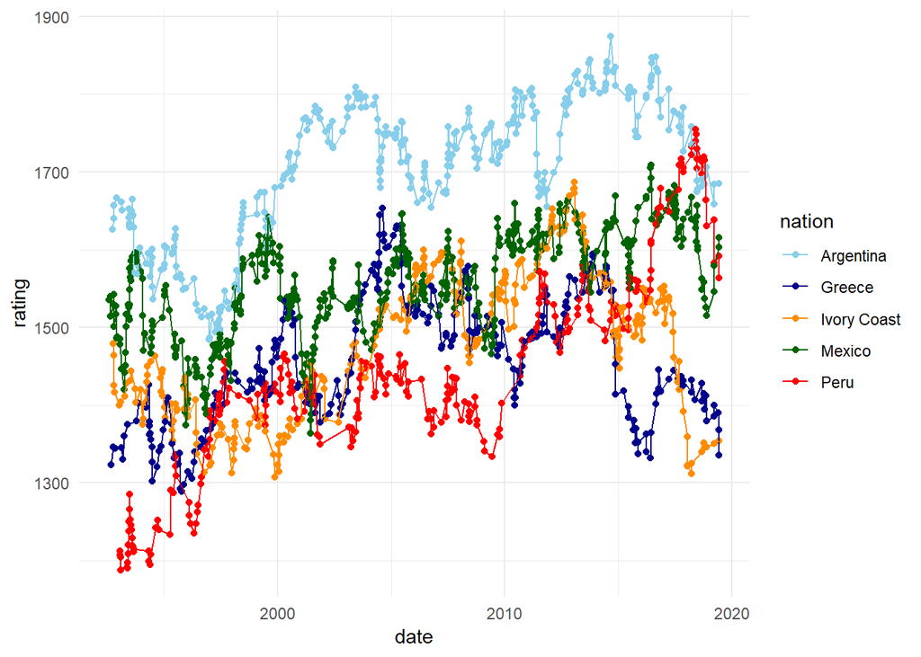

```r
teams <- elo_data %>%
  filter(rating > 1600) %>%
  .$nation %>%
  unique() %>%
  .[sample(length(.), 5)]

p1 <- elo_data %>%
  filter(nation %in% teams) %>%
  ggplot(aes(x = date, y = rating, colour = nation, group = nation)) +
  geom_point() +
  geom_line() +
  scale_colour_manual(values = c("skyblue", "darkblue", "darkorange", "darkgreen", "red")) +
  scale_colour_manual(values = c("skyblue",
                                 "darkblue",
                                 "darkorange",
                                 "darkgreen",
                                 "red")) +
  theme_minimal()

plot(p1)
```

I’m pretty happy with how the code works. With a more complete dataset of matches, and also the time to properly filter countries in and out as they are formed/dissolved, I think it would make a pretty viable answer, however, I wanted to be as accurate as possible, and I can’t compete with the official-unofficial ratings of eloratings.net.

## Dynamic Scraping

When scraing data for blog posts, I typically rely on rvest and it’s read_html(url) function. However, while this works for the static websites which make up the vast majority of sites containing tables of data, it struggles with websites that use javascript to dynamically generate pages.

Eloratings.net is one such website which rvest is unable to scrape. E.g.

```r
url <- "https://eloratings.net/Brazil"

read <-read_html(url) %>%
  html_nodes("#mainheader")

read
```

```
## {xml_nodeset (1)}
## [1] <h1 id="mainheader" class="mainheader"></h1>
```

Instead, what we want to do is save a copy of the generated page as a .html file and then read that into R using read_html(). Luckily, a way exists to do just that, using the (now deprecated, but still working) [PhantomJS headless browser](http://phantomjs.org/). Much of the code I used to get going with this is adapted from a tutorial [here](https://velaco.github.io/how-to-scrape-data-from-javascript-websites-with-R/).

First you want to install PhantomJS from the above website and run through it’s [quick start guide](http://phantomjs.org/quick-start.html). This is a pretty thorough guide, I would say that there are really only three steps from installation to getting going:

1. [Add phantomjs to the system PATH](https://www.howtogeek.com/118594/how-to-edit-your-system-path-for-easy-command-line-access/)
2. Open a text editor and save one of the tutorial scripts as filename.js
3. run > phantomjs C:/Users/usr/path/to/file.js in a command line console

The file we’re going to use to render the javescript pages and then save the html is below:

```r
// scrapes a given url (for eloratings.net)

// create a webpage object
var page = require('webpage').create(),
  system = require('system')

// the url for each country provided as an argument
country= system.args[1];

// include the File System module for writing to files
var fs = require('fs');

// specify source and path to output file
// we'll just overwirte iteratively to a page in the same directory
var path = 'elopage.html'

page.open(country, function (status) {
  var content = page.content;
  fs.write(path,content,'w')
  phantom.exit();
});
```

(which, again, is stolen and adapted from [here](https://velaco.github.io/how-to-scrape-data-from-javascript-websites-with-R/))

This is saved as scrape_ELO.js in the static directory of my blog folder.

To keep everything in R, we can use the system() family of functions, which provides acess to the OS command line. Though the referenced tutorial uses system(), it relies on scraping a single referenced page. To iteratively scrape every country, we’ll need to provide an argument (country) which will contain the link to the page on eloratings.net for that country.

E.g. for Brazil we will provide “https://www.eloratings.net/Brazil” as the country argument

```r
phantom_dir <- "C:/Users/path/to/scrape_ELO/"
country_url <- "https://www.eloratings.net/Brazil"

# use system2 to invoke phantomjs via it's executable
system2("C:/Users/robwh/Downloads/phantomjs-2.1.1-windows/bin/phantomjs.exe",
        #provide the path to the scraping script and the country url as argument
        args = c(file.path(phantom_dir, "scrape_ELO.js"), country_url))
```

We can then read in this saved html page using rvest as per usual and recover the information therein.

```r
page <- read_html("elopage.html")

country_name <- page %>%
  html_nodes("#mainheader") %>%
  html_text() %>%
  gsub("Elo Ratings: ", "", .)

country_name
```

```
## [1] "Brazil"
```

I’m not going to include my full script for scraping eloratings.net as usually a reason for doing this obscuring of the data is to prevent exaclty what I’m doing. Instead I’ll give a skeleton function of the one I use. If you are having problems with setting up phantomjs to scrape pages, my contact details are listed on my [blog homepage](http://www.robert-hickman.eu/)

```r
scrape_nation <- function(country) {
  # download the page
  url <- paste0("https://eloratings.net/", country)
  system2("C:/Users/robwh/Downloads/phantomjs-2.1.1-windows/bin/phantomjs.exe",
          args = c(file.path(phantom_dir, "scrape_ELO.js"), url))

  # read in downloaded page
  page <- read_html("elopage.html")

  # recover information
  country_name <- page %>%
    html_nodes("#mainheader") %>%
    html_text() %>%
    gsub("Elo Ratings: ", "", .)

  opposing <- page %>%
      html_nodes(".r1 a") %>%
      html_text()

  teams <- page %>%
      html_nodes(".r1")

  fixtures <- map2_df(teams, opposing, split_teams)

  ratings <- page %>%
    html_nodes(".r4") %>%
    html_text() %>%
    map_df(., split_ratings)

  rankings <- page %>%
    html_nodes(".r6") %>%
    map_df(., split_rankings)

  dates <- page %>%
    html_nodes(".r0") %>%
    html_text() %>%
    map_df(., convert_date)

  # bind into a data frame
  df <- fixtures %>%
    cbind(., ratings) %>%
    cbind(., rankings) %>%
    cbind(., dates) %>%
    mutate(table_country = country_name)
}

elO_data <- map_df(country_links, scrape_nation)
```

Finally, we want to convert this to long format. We have two observations per country and any point in time- the rating, and the ranking. I’m going to filter out just the ranking, as that’s what the questions ask, but if anything there’s possibly more information in the rating data.

```r
elo_data %<>%
  # rename and select variables
  select(date, home, away, rating_home = r1, rating_away = r2, ranking_home = ranking1, ranking_away = ranking2) %>%
  # melt twice to convert to long format
  gather("location", "nation", -rating_home, -rating_away, -ranking_home, -ranking_away, -date) %>%
  gather("measure", "value", -nation, -date, -location) %>%
  # take only relevant information
  filter((location == "home" & measure %in% c("rating_home", "ranking_home")) |
           (location == "away" & measure %in% c("rating_away", "ranking_away"))) %>%
  separate(measure, into = c("measure", "location"), "_") %>%
  # filter out relevant data
  filter(!duplicated(.)) %>%
  filter(date > "1992-01-01") %>%
  filter(measure == "ranking") %>%
  select(-measure, ranking = value, -location)
```

## Answering the Question

So now we have a database of Premier League players’ nationalities, and also of the ELO rankings of countries since 1992, we can answer the original questions.

First we need to make sure that the data can join to each other, which means making sure that the nation names are common between the two data sets.

```r
# get unique names for countries in both data sets
squad_teams <- unique(squads$nation)
rating_teams <- unique(elo_data$nation)

# find non joining country names
squad_teams[!squad_teams %in% rating_teams]
```

```
##  [1] "Ireland Republic"       "Trinidad and Tobago"
##  [3] "Czech Republic"         "Macedonia FYR"
##  [5] "St. Kitts and Nevis"    "Bosnia and Herzegovina"
##  [7] "Congo DR"               "Antigua and Barbuda"
##  [9] "Korea Republic"         "Curacao"
## [11] "Cape Verde Islands"     "Equatorial Guinea"
```

Some are missing where country names follow different convetion- e.g. the Democratic Republic of Congo is named DR Congo in one, and Congo DR in the other. We can quickly convert these odd countries and join the two data sets together using dplyr. Then we can get an idea of the national rankings of the nationality of Premier League players since it’s inception

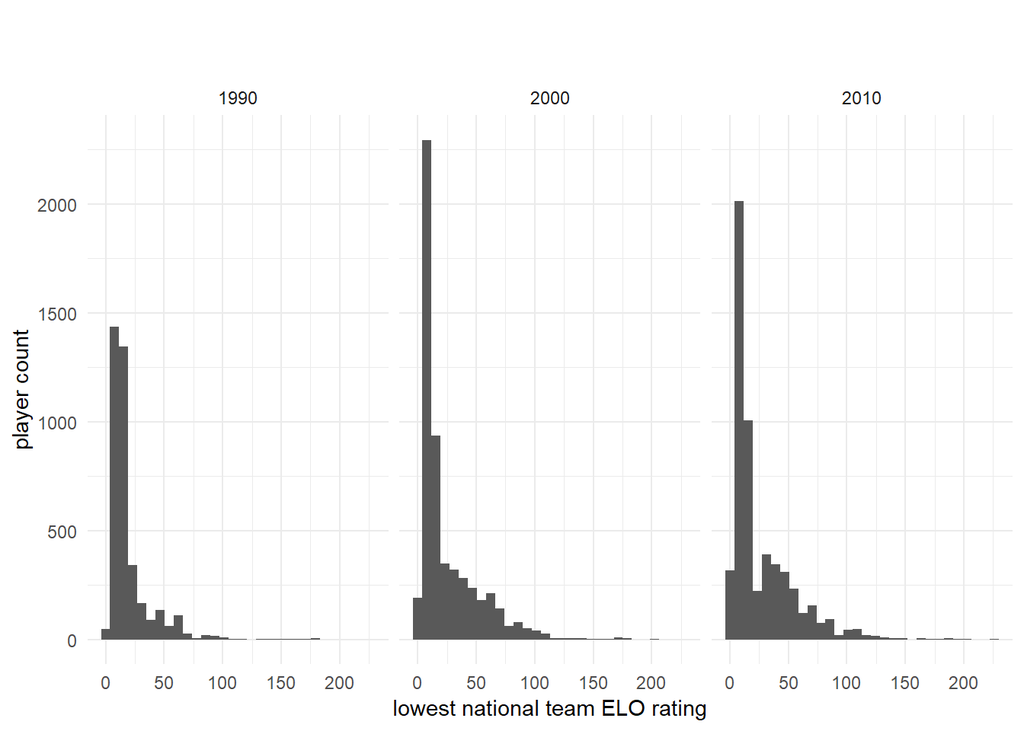

```r
# rename mismatching nations
elo_data %<>%
  mutate(nation = case_when(
    grepl("^Ireland", nation) ~ "Ireland Republic",
    grepl("^Czechia", nation) ~ "Czech Republic",
    grepl("Trinidad/Tobago", nation) ~ "Trinidad and Tobago",
    grepl("Macedonia", nation) ~ "Macedonia FYR",
    grepl("St Kitts and Nevis", nation) ~ "St. Kitts and Nevis",
    grepl("Bosnia/Herzeg", nation) ~ "Bosnia and Herzegovina",
    grepl("DR Congo", nation) ~ "Congo DR",
    grepl("Antigua/Barbuda", nation) ~ "Antigua and Barbuda",
    grepl("South Korea", nation) ~ "Korea Republic",
    grepl("Curaçao", nation) ~ "Curacao",
    grepl("Cape Verde", nation) ~ "Cape Verde Islands",
    grepl("Equat Guinea", nation) ~ "Equatorial Guinea",
    TRUE ~ nation
  ))

players_national_elo <- squads %>%
  # convert dates
  mutate(year = as.numeric(year)) %>%
  # join elo rating data
  left_join(., elo_data, by = "nation") %>%
  # take only relevant data per season
  filter(date < as.Date(paste0(year, "-06-30")) &
           date > as.Date(paste0(year-1, "-07-01")))

p2 <- players_national_elo %>%
  arrange(ranking) %>%
  filter(!duplicated(paste(player, team, year), fromLast = TRUE)) %>%
  mutate(decade = case_when(
    year < 2000 ~ "1990",
    year < 2010 ~ "2000",
    year < 2020 ~ "2010"
  )) %>%
  ggplot(aes(ranking)) +
  geom_histogram() +
  labs(title = "",
       subtitle = "",
       x = "lowest national team ELO rating",
       y = "player count") +
  theme_minimal() +
  facet_wrap(~decade)

plot(p2)
```

We can easily then take the players with the worst national team ranking by arranging by the ranking of national teams (and removing duplicate players so it isn’t just filled with the same 2/3 names)

```r
worst_national_team_players <- players_national_elo %>%
  # arrange rating from low to high
  arrange(-ranking) %>%
  # remove duplicated players
  filter(!duplicated(player)) %>%
  # select only relevant info
  select(year, team, player, url, nation, ranking)

# show the 25 players with the worst ranking their nation had during that time
head(select(worst_national_team_players, -url), n = 25)
```

|  | year | team | player | nation | ranking |
| --- | --- | --- | --- | --- | --- |
| 1 | 2015 | queens-park-rangers | Brandon Comley | Montserrat | 227 |
| 2 | 2004 | fulham | Zesh Rehman | Pakistan | 204 |
| 3 | 2012 | wolverhampton-wanderers | George Elokobi | Somalia | 199 |
| 4 | 2014 | aston-villa | Leandro Bacuna | Curacao | 188 |
| 5 | 2013 | swansea-city | Kemy Agustien | Curacao | 186 |
| 6 | 2015 | swansea-city | Kenji Gorré | Curacao | 186 |
| 7 | 1998 | manchester-united | Danny Higginbotham | Gibraltar | 181 |
| 8 | 1999 | wimbledon | Carl Cort | Guyana | 179 |
| 9 | 2007 | sheffield-united | Mikele Leigertwood | Antigua and Barbuda | 179 |
| 10 | 2007 | watford | Moses Ashikodi | Antigua and Barbuda | 179 |

[output cut: 15 more lines]

We can then find the players with the worst national team rankings by joining in and selecting for teams that won the league. As the nation’s world ranking needs to have been acheived during that season, a small function to find a nations lowest ranking during a time frame (from august of the preceeding year to june just after they would have been crowned champions) is required.

```r
epl_winners <- data.frame(
  champion = c(
    "manchester-united",
    "manchester-united",
    "blackburn-rovers",
    "manchester-united",
    "manchester-united",
    "arsenal",
    "manchester-united",
    "manchester-united",
    "manchester-united",
    "arsenal",
    "manchester-united",
    "arsenal",
    "chelsea",
    "chelsea",
    "manchester-united",
    "manchester-united",
    "manchester-united",
    "chelsea",
    "manchester-united",
    "manchester-city",
    "manchester-united",
    "manchester-city",
    "chelsea",
    "leicester-city",
    "chelsea",
    "manchester-city",
    "manchester-city"),
  year = 1993:2019
)

epl_winning_squads <- players_national_elo %>%
  left_join(., epl_winners, by = "year") %>%
  filter(team == champion) %>%
  filter(date < as.Date(paste0(year, "-06-30")) &
           date > as.Date(paste0(year-1, "-07-01"))) %>%
  arrange(-ranking) %>%
  filter(!duplicated(paste(player, year), fromLast = TRUE)) %>%
  select(year, team, player, url, apps = appearances, sub_apps = sub_appearances, nation, ranking)

head(epl_winning_squads, n = 25)
```

|  | year | team | player | url | apps | sub_apps | nation | ranking |
| --- | --- | --- | --- | --- | --- | --- | --- | --- |
| 1 | 1998 | arsenal | Christopher Wreh | /players/christopher-wreh-4/ | 7 | 9 | Liberia | 110 |
| 2 | 2010 | chelsea | Gaël Kakuta | /players/gaël-kakuta-229677/ | 0 | 1 | Congo DR | 103 |
| 3 | 2013 | manchester-united | Jonny Evans | /players/jonny-evans-225369/ | 21 | 2 | Northern Ireland | 97 |
| 4 | 2002 | arsenal | Igors Stepanovs | /players/igors-stepanovs-7660/ | 6 | 0 | Latvia | 96 |
| 5 | 2004 | arsenal | Justin Hoyte | /players/justin-hoyte-20807/ | 0 | 1 | Trinidad and Tobago | 96 |
| 6 | 2009 | manchester-united | Manucho | NA | 0 | 1 | Angola | 84 |
| 7 | 2006 | chelsea | Eidur Gudjohnsen | /players/eidur-gudjohnsen-1374/ | 16 | 10 | Iceland | 74 |
| 8 | 2001 | manchester-united | David Healy | /players/david-healy-301/ | 0 | 1 | Northern Ireland | 71 |
| 9 | 2003 | manchester-united | Roy Carroll | /players/roy-carroll-944/ | 8 | 2 | Northern Ireland | 69 |
| 10 | 2016 | leicester-city | Yohan Benalouane | /players/yohan-benalouane-249796/ | 0 | 4 | Tunisia | 68 |

[output cut: 15 more lines]

## Extra Credit

```r
get_international_matches <- function(url) {
  if(!is.na(url)) {
    read <- paste0("https://www.11v11.com", url) %>%
      read_html() %>%
      html_nodes("#matchHistory") %>%
      html_table(fill = TRUE)

    if(length(read) > 1) {
      national_team_data <- read %>%
      .[[2]] %>%
        .[1:2] %>%
        mutate(url = url)
    } else {
      national_team_data <- NULL
    }
  }
}

lowest_ranked_appearances <- worst_national_team_players$url %>%
  .[1:20] %>%
  map_df(., get_international_matches) %>%
  mutate(date = as.Date(Date, "%d %b %Y")) %>%
  select(date, match = Match, url) %>%
  left_join(., players_national_elo, by = "url") %>%
  filter(unlist(map2(nation, match, grepl))) %>%
  filter(date.x == date.y) %>%
  arrange(-ranking) %>%
  filter(!duplicated(player, fromLast = TRUE))

head(lowest_ranked_appearances, n = 10)
```

|  | date.x | match | url | player | position | appearances | sub_appearances | nation | year | team | date.y | ranking |
| --- | --- | --- | --- | --- | --- | --- | --- | --- | --- | --- | --- | --- |
| 1 | 2018-11-13 | Philippines v Singapore | /players/neil-etheridge-236585/ | Neil Etheridge | Goalkeeper | 38 | 0 | Philippines | 2019 | cardiff-city | 2018-11-13 | 165 |
| 2 | 2017-07-09 | Curacao v Jamaica | /players/cuco-martina-247568/ | Cuco Martina | Defender | 20 | 1 | Curacao | 2018 | everton | 2017-07-09 | 141 |
| 3 | 2004-05-20 | Cuba v Grenada | /players/jason-roberts-4254/ | Jason Roberts | Forward | 4 | 6 | Grenada | 2004 | portsmouth | 2004-05-20 | 131 |
| 4 | 2008-03-26 | Barbados v Dominica | /players/emmerson-boyce-4469/ | Emmerson Boyce | Defender/Midfielder | 24 | 1 | Barbados | 2008 | wigan-athletic | 2008-03-26 | 126 |
| 5 | 2019-06-25 | Jamaica v Curacao | /players/leandro-bacuna-236266/ | Leandro Bacuna | Defender/Midfielder | 4 | 7 | Curacao | 2019 | cardiff-city | 2019-06-25 | 111 |
| 6 | 2003-06-07 | Estonia v Andorra | /players/mart-poom-169/ | Mart Poom | Goalkeeper | 4 | 0 | Estonia | 2003 | sunderland | 2003-06-07 | 85 |

```r
lowest_champ_appearances <- epl_winning_squads$url %>%
  .[1:20] %>%
  map_df(., get_international_matches) %>%
  mutate(date = as.Date(Date, "%d %b %Y")) %>%
  select(date, match = Match, url) %>%
  left_join(., players_national_elo, by = "url") %>%
  filter(unlist(map2(nation, match, grepl))) %>%
  filter(date.x == date.y) %>%
  arrange(-ranking) %>%
  filter(!duplicated(player, fromLast = TRUE))

head(lowest_champ_appearances, n = 10)
```

|  | date.x | match | url | player | position | appearances | sub_appearances | nation | year | team | date.y | ranking |
| --- | --- | --- | --- | --- | --- | --- | --- | --- | --- | --- | --- | --- |
| 1 | 1999-02-28 | Liberia v Algeria | /players/christopher-wreh-4/ | Christopher Wreh | Forward | 3 | 9 | Liberia | 1999 | arsenal | 1999-02-28 | 109 |
| 2 | 2003-04-30 | Latvia v San Marino | /players/igors-stepanovs-7660/ | Igors Stepanovs | Defender/Centre back | 2 | 0 | Latvia | 2003 | arsenal | 2003-04-30 | 85 |
| 3 | 2003-02-12 | Northern Ireland v Finland | /players/roy-carroll-944/ | Roy Carroll | Goalkeeper | 8 | 2 | Northern Ireland | 2003 | manchester-united | 2003-02-12 | 70 |
| 4 | 2008-08-20 | Scotland v Northern Ireland | /players/david-healy-301/ | David Healy | Forward | 0 | 10 | Northern Ireland | 2009 | sunderland | 2008-08-20 | 60 |
| 5 | 2007-03-27 | China PR v Uzbekistan | /players/dong-fang-zhou-224537/ | DONG Fang Zhou | Forward | 1 | 0 | China | 2007 | manchester-united | 2007-03-27 | 57 |
| 6 | 2001-09-01 | Iceland v Czech Republic | /players/eidur-gudjohnsen-1374/ | Eidur Gudjohnsen | Midfielder/Forward | 26 | 6 | Iceland | 2002 | chelsea | 2001-09-01 | 51 |
| 7 | 2018-06-09 | Tunisia v Spain | /players/yohan-benalouane-249796/ | Yohan Benalouane | Defender | 1 | 0 | Tunisia | 2018 | leicester-city | 2018-06-09 | 49 |
| 8 | 2000-09-03 | Trinidad and Tobago v Canada | /players/dwight-yorke-304/ | Dwight Yorke | Forward | 15 | 7 | Trinidad and Tobago | 2001 | manchester-united | 2000-09-03 | 45 |
| 9 | 2017-09-04 | Northern Ireland v Czech Republic | /players/jonny-evans-225369/ | Jonny Evans | Defender | 26 | 2 | Northern Ireland | 2018 | west-bromwich-albion | 2017-09-04 | 37 |
| 10 | 2014-10-15 | Algeria v Malawi | /players/riyad-mahrez-241798/ | Riyad Mahrez | Midfielder/Forward | 25 | 5 | Algeria | 2015 | leicester-city | 2014-10-15 | 34 |